# Analysis of tweets

For this analysis we collected tweets containing the set of public health keywords using the free Twitter Search API, which returns a random portion of matching tweets from the past seven days. This notebook does not include the collection process, but the analysis of the collected tweets.

### Select language using one of the following codes:

- en (English, default option)
- de (German)
- es (Spanish)
- fr (French)
- pt (Portuguese)

```python
language = 'pt'
```

```python
language_ref = { 'en' : { 'name' : 'English', 'min_coocurrence' : 10, 'min_coocurrence_hashtags' : 2},
                 'de' : { 'name' : 'German', 'min_coocurrence' : 1, 'min_coocurrence_hashtags' : 1},
                 'es' : { 'name' : 'Spanish', 'min_coocurrence' : 1, 'min_coocurrence_hashtags' : 1},
                 'fr' : { 'name' : 'French', 'min_coocurrence' : 1, 'min_coocurrence_hashtags' : 1},
                 'pt' : { 'name' : 'Portuguese', 'min_coocurrence' : 1, 'min_coocurrence_hashtags' : 1},
               }
```

## Loading tweets

```python
import os

tweets_folder = os.path.join("..", "data", "tweets", language)
tweets_climate_filename_prefix = "tweets_climate." + language + "."
tweets_health_filename_prefix = "tweets_health." + language + "."

tweets_climate = {}
tweets_health = {}
```

```python
import pandas as pd
import csv

def load_tweets(filename):
    tweets = {}
    with open(filename) as csvfile:
        reader = csv.DictReader(csvfile)
        for row in reader:
            tweets[row['id']] = row
    return tweets
```

```python
import time
from ast import literal_eval
from textblob import TextBlob

def get_location(tweet):
    try:
        user = eval(str(tweet['user']))
        location = user['location']
    except:
        location = 'not_specified'
    if location == '':
        location = 'not_specified'
    return location

def get_date(tweet):
    timestamp = tweet['created_at']
    try:
        parsed_timestamp = time.strptime(timestamp, '%a %b %d %H:%M:%S %z %Y')
        month_year = "%s %s" % (parsed_timestamp.tm_mon, parsed_timestamp.tm_year)
    except:
        month_year = 'missing'
    return month_year

def get_text(tweet):
    text = str(tweet['text'])
    return text

def get_user(tweet):
    try:
        user = eval(str(tweet['user']))
        username = user['screen_name']
    except:
        username = 'not_specified'
    return "@" + username

def get_hashtags(tweet):
    hashtags = []
    try:
        hashtags_entities = eval(str(tweet['entities']))['hashtags']
        for hashtag_entity in hashtags_entities:
            hashtags.append("#" + hashtag_entity['text'])
    except:
        pass
    return hashtags

def get_user_mentions(tweet):
    user_mentions = []
    try:
        user_mentions_entities = eval(str(tweet['entities']))['user_mentions']
        for user_mention_entity in user_mentions_entities:
            user_mentions.append("@" + user_mention_entity['screen_name'])
    except:
        pass
    return user_mentions

def get_sentiment(tweet_text):
    if language == 'en':
        sentiment = TextBlob(tweet_text).sentiment
        if sentiment.polarity >= 0.1:
            polarity = 'positive'
        else:
            if sentiment.polarity < 0.1 and sentiment.polarity > -0.1:
                polarity = 'neutral'
            else:
                polarity = 'negative'
        if sentiment.subjectivity >= 0.5:
            subjectivity = 'subjective'
        else:
            subjectivity = 'objective'
    else:
        polarity = 'no_polarity'
        subjectivity = 'no_subjectivity'

    return (polarity, subjectivity)

def process_tweet(tweet):
    date = get_date(tweet)
    location = get_location(tweet)
    user = get_user(tweet)
    text = get_text(tweet)
    sentiment = get_sentiment(text)
    hashtags = get_hashtags(tweet)
    user_mentions = get_user_mentions(tweet)
    return {'date' : date, 'location' : location, 'text' : text, 'hashtags' : hashtags, 'user' : user, 'sentiment' : sentiment, 'user_mentions' : user_mentions}
```

```python
from os import listdir

files = listdir(tweets_folder)
for f in files:
    if tweets_health_filename_prefix in f:
        print("Loading %s" % f)
        for (tweet_id, tweet) in load_tweets(os.path.join(tweets_folder, f)).items():
            tweets_health[tweet_id] = process_tweet(tweet)
#    if tweets_climate_filename_prefix in f:
#        print("Loading %s" % f)
#        for (tweet_id, tweet) in load_tweets(os.path.join(tweets_folder, f)).items():
#            tweets_climate[tweet_id] = process_tweet(tweet)
```

```
Loading tweets_health.pt.2018-08-13 21:32:49.csv
Loading tweets_health.pt.2018-08-14 01:48:25.csv
Loading tweets_health.pt.2018-08-14 20:16:00.csv
Loading tweets_health.pt.2018-08-13 16:27:17.csv
Loading tweets_health.pt.2018-08-13 15:33:00.csv
Loading tweets_health.pt.2018-08-14 15:18:45.csv
Loading tweets_health.pt.2018-08-13 15:53:20.csv
Loading tweets_health.pt.2018-08-13 15:43:09.csv
Loading tweets_health.pt.2018-08-15 01:04:33.csv
```

```python
print("Climate tweets: %d - Health tweets: %d" % (len(tweets_climate), len(tweets_health)))
```

```
Climate tweets: 0 - Health tweets: 60091
```

```python
df_tweets_climate = pd.DataFrame.from_dict(tweets_climate, orient='index')
df_tweets_climate.head(10)
```

```python
df_tweets_health = pd.DataFrame.from_dict(tweets_health, orient='index')
df_tweets_health.head(10)
```

|  | date | location | text | hashtags | user | sentiment | user_mentions |
| --- | --- | --- | --- | --- | --- | --- | --- |
| 1029024175870996482 | 8 2018 | San Jose, CA | RT @oiejuao: vontade daquilo q começa com s\n\... | [] | @mathteeixeira | (no_polarity, no_subjectivity) | [@oiejuao] |
| 1029024187732684801 | 8 2018 | Rio de Janeiro, Brasil | RT @TVCoriscoPI: SAÚDE\nConheça os dez travess... | [] | @Jorge_Henri2001 | (no_polarity, no_subjectivity) | [@TVCoriscoPI] |
| 1029024190073061376 | 8 2018 | Sete Lagoas, Brasil | Psicólogo em Sete Lagoas https://t.co/vERxdDU4... | [] | @A11Bell | (no_polarity, no_subjectivity) | [] |
| 1029024193843789825 | 8 2018 | waiting | eu irresponsável não terminei de tomar um anti... | [] | @qasases | (no_polarity, no_subjectivity) | [] |
| 1029024200227516416 | 8 2018 | Luiz Alves, Brasil | Parabéns sua puta barata aproveita teu dia tud... | [] | @GordertIgor | (no_polarity, no_subjectivity) | [] |
| 1029024202802778113 | 8 2018 | not_specified | @leticiaizidoro Parabéns Lele! Q Deus abençoe ... | [] | @CarlaIndiaFF | (no_polarity, no_subjectivity) | [@leticiaizidoro] |
| 1029024218011365381 | 8 2018 | not_specified | RT @animaisproteger: Meu nome é Vovó Tata, sou... | [] | @CamilaG_Souza | (no_polarity, no_subjectivity) | [@animaisproteger] |
| 1029024221186478081 | 8 2018 | not_specified | RT @gallifreyniana: Um feliz dia dos pais pro ... | [] | @llysnathalia | (no_polarity, no_subjectivity) | [@gallifreyniana] |
| 1029024223992393729 | 8 2018 | Igrejinha, Brasil | Ronaldo:\n\n&gt;"Não se faz copa com hospitais... | [] | @FleschPedro | (no_polarity, no_subjectivity) | [] |
| 1029024230938165250 | 8 2018 | a mystical place ✩ namoradjinh | RT @shaidersolutt: "a partir d hj n irei mais ... | [] | @cabeleilanegra | (no_polarity, no_subjectivity) | [@shaidersolutt] |

## Keywords

```python
import json
import os
import re

keywords_file = os.path.join("..", "keywords", language + ".json")

climate_dict = []
health_dict = []
compound_terms = []

def normalise_keywords(dictionary): #lowercases and handles compounds
    for i in range(0, len(dictionary)):
        keyword = dictionary[i].lower()
        compound = keyword.replace(' ','_')
        if compound != keyword:
            keyword = compound
            words = tuple(compound.split('_'))
            compound_terms.append(words)
        dictionary[i] = keyword
    return dictionary

def generate_hashtags(dictionary):
    hashtags_dict = []
    for keyword in dictionary:
        hashtags_dict.append("#" + keyword.replace('_',''))
    return hashtags_dict

with open(keywords_file) as f:
    data = json.load(f)

climate_dict = normalise_keywords(data['climate'])
health_dict = normalise_keywords(data['health'])

climate_hashtag_dict = generate_hashtags(climate_dict)
health_hashtag_dict = generate_hashtags(health_dict)
```

```python
health_dict
```

```
['malária',
 'diarréia',
 'infecção',
 'doença',
 'sars',
 'sarampo',
 'pneumonia',
 'epidemia',
 'pandemia',
 'saúde_pública',
 'saúde',
 'epidemiologia',
 'saúde',
 'saúde',
 'mortalidade',
 'morbidade',
 'nutrição',
 'doença',
 'doença_infecciosa',
 'ncd',
 'doença_não_transmissível',
 'doença_contagiosa_ou_transmissível',
 'poluição_do_ar',
 'nutrição',
 'desnutrição',
 'transtorno_mental',
 'retardo_de_crescimento']
```

```python
health_hashtag_dict
```

```
['#malária',
 '#diarréia',
 '#infecção',
 '#doença',
 '#sars',
 '#sarampo',
 '#pneumonia',
 '#epidemia',
 '#pandemia',
 '#saúdepública',
 '#saúde',
 '#epidemiologia',
 '#saúde',
 '#saúde',
 '#mortalidade',
 '#morbidade',
 '#nutrição',
 '#doença',
 '#doençainfecciosa',
 '#ncd',
 '#doençanãotransmissível',
 '#doençacontagiosaoutransmissível',
 '#poluiçãodoar',
 '#nutrição',
 '#desnutrição',
 '#transtornomental',
 '#retardodecrescimento']
```

```python
climate_dict
```

```
['mudanças_climáticas',
 'aquecimento_global',
 'temperatura',
 'clima_extremo',
 'mudança_ambiental_global',
 'variabilidade_climática',
 'estufa',
 'baixo_carbono',
 'gee',
 'energia_renovável',
 'emissões_de_carbono',
 'emissões_de_co2',
 'poluentes_climáticos']
```

```python
climate_hashtag_dict
```

```
['#mudançasclimáticas',
 '#aquecimentoglobal',
 '#temperatura',
 '#climaextremo',
 '#mudançaambientalglobal',
 '#variabilidadeclimática',
 '#estufa',
 '#baixocarbono',
 '#gee',
 '#energiarenovável',
 '#emissõesdecarbono',
 '#emissõesdeco2',
 '#poluentesclimáticos']
```

## Analysing Tweets

```python
location_threshold = 20
```

```python
## Attempt to normalise location names by inferring the country when it's the last part of a location name.
## This is not used in the remaining of the notebook.

import re

place_country_regex = re.compile(r"^(?P<place>[^,]+?)[ ]*,[ ]*(?P<country>[^,$]+)[ \.]*$")

inferred_countries = {}
inferred_locations = {}

def infer_country(location):
    match = place_country_regex.match(location)
    if match:
        inferred_countries[match.group('place')] = match.group('country')
        inferred_countries[location] = match.group('country')

def get_inferred_location(location):
    if location in inferred_countries.keys():
        return inferred_countries[location]
    else:
        return location

for tweet in tweets_health.values():
    infer_country(tweet['location'])

for tweet in tweets_health.values():
    inferred_location = get_inferred_location(tweet['location'])
    inferred_locations[inferred_location] = inferred_locations.get(inferred_location, 0) + 1
```

```python
locations = {}
dates = {}
sentiments = {}

for tweet in tweets_health.values():
    locations[tweet['location']] = locations.get(tweet['location'], 0) + 1
    dates[tweet['date']] = dates.get(tweet['date'], 0) + 1

    (polarity, subjectivity) = tweet['sentiment']
    sentiments[polarity] = sentiments.get(polarity, 0) + 1
    sentiments[subjectivity] = sentiments.get(subjectivity, 0) + 1
```

```python
print("%d %d" % (len(locations.keys()), len(inferred_locations.keys())))
```

```
15205 11531
```

```python
df_locations = pd.DataFrame(sorted(locations.items(), key=lambda k: k[1], reverse=True), columns=["Location", "Number of tweets"])
df_locations.loc[(df_locations["Number of tweets"] >= 100)]
```

|  | Location | Number of tweets |
| --- | --- | --- |
| 0 | not_specified | 13974 |
| 1 | Brasil | 2384 |
| 2 | Sete Lagoas, Brasil | 2285 |
| 3 | Rio de Janeiro, Brasil | 2140 |
| 4 | São Paulo, Brasil | 1429 |
| 5 | Sete Lagoas, Minas Gerais | 645 |
| 6 | Belo Horizonte, Brasil | 511 |
| 7 | Rio de Janeiro | 493 |
| 8 | São Paulo | 443 |
| 9 | Brasília, Brasil | 413 |
| 10 | Brazil | 380 |
| 11 | Porto Alegre, Brasil | 276 |
| 12 | Curitiba, Brasil | 247 |
| 13 | Minas Gerais, Brasil | 230 |
| 14 | 021 | 207 |
| 15 | Rio Grande do Sul, Brasil | 204 |
| 16 | Recife, Brasil | 204 |
| 17 | Portugal | 194 |
| 18 | Manaus, Brasil | 188 |
| 19 | Fortaleza, Brasil | 146 |
| 20 | Santa Catarina, Brasil | 138 |
| 21 | Goiânia, Brasil | 137 |
| 22 | Brasília | 133 |
| 23 | 027 | 123 |
| 24 | Salvador, Brasil | 122 |
| 25 | Belo Horizonte, Minas Gerais | 119 |
| 26 | Belo Horizonte | 118 |
| 27 | RJ | 117 |
| 28 | Petrópolis, Brasil | 113 |
| 29 | BH | 113 |
| 30 | Porto, Portugal | 111 |
| 31 | Sao Paulo, Brazil | 109 |
| 32 | Espírito Santo, Brasil | 108 |
| 33 | Lisboa, Portugal | 106 |

```python
df_dates = pd.DataFrame(sorted(dates.items(), key=lambda k: k[1], reverse=True), columns=["Date", "Number of tweets"])
df_dates
```

|  | Date | Number of tweets |
| --- | --- | --- |
| 0 | 8 2018 | 60091 |

```python
df_sentiments = pd.DataFrame(sorted(sentiments.items(), key=lambda k: k[1], reverse=True), columns=["Sentiment", "Number of tweets"])
df_sentiments
```

|  | Sentiment | Number of tweets |
| --- | --- | --- |
| 0 | no_polarity | 60091 |
| 1 | no_subjectivity | 60091 |

```python
from nltk.tokenize import MWETokenizer, TweetTokenizer
import re

tweet_tokenizer = TweetTokenizer()
tokenizer = MWETokenizer(compound_terms)

per_location = {}
average_per_location = {}
proportion_per_location = {}
per_date = {}
average_per_date = {}
proportion_per_date = {}
per_sentiment = {}
average_per_sentiment = {}
proportion_per_sentiment = {}
per_user = {}
proportion_per_user = {}
histogram_number_of_mentions = {}

global_count_health_keywords = {}
global_count_climate_keywords = {}
global_count_health = 0
global_count_intersection = 0

global_health_contexts = []
global_health_hashtag_contexts = []
global_health_user_mentions_contexts = []
global_intersection_contexts = []
global_intersection_hashtag_contexts = []
global_intersection_user_mentions_contexts = []

cooccurrence_matrix = {}
hashtags_cooccurrence_matrix = {}
mixed_cooccurrence_matrix = {}

for termset in ["health", "intersection"]:
    per_location[termset] = {}
    average_per_location[termset] = {}
    proportion_per_location[termset] = {}
    per_date[termset] = {}
    average_per_date[termset] = {}
    proportion_per_date[termset] = {}
    per_sentiment[termset] = {}
    average_per_sentiment[termset] = {}
    proportion_per_sentiment[termset] = {}
    per_user[termset] = {}
    proportion_per_user[termset] = {}
    histogram_number_of_mentions[termset] = {}

for tweet in tweets_health.values():
    text = tweet['text']
    hashtags = tweet['hashtags']
    location = tweet['location']
    date = tweet['date']
    (polarity, subjectivity) = tweet['sentiment']
    user  = tweet['user']
    user_mentions = tweet['user_mentions']

    wordlist = tweet_tokenizer.tokenize(text.lower())
    compounds_wordlist = tokenizer.tokenize(wordlist)
    filtered_compounds_wordlist = [w for w in compounds_wordlist if (len(w) > 3)]

    health_contexts = []
    total_intersection_mentions = 0
    total_health_mentions = 0

    health_words = []
    climate_words = []
    for word in filtered_compounds_wordlist:
        if word in health_dict:
            total_health_mentions += 1
            context = filtered_compounds_wordlist
            health_contexts.append(context)
            global_health_contexts.extend(context)
            global_health_hashtag_contexts.extend(hashtags)
            global_health_user_mentions_contexts.extend(user_mentions)
            global_count_health_keywords[word] = global_count_health_keywords.get(word, 0) + 1
            health_words.append(word)

        if word in climate_dict:  # means intersection, since we are processing health tweets here
            total_intersection_mentions += 1
            context = filtered_compounds_wordlist
            global_intersection_contexts.extend(context)
            global_intersection_hashtag_contexts.extend(hashtags)
            global_intersection_user_mentions_contexts.extend(user_mentions)
            global_count_climate_keywords[word] = global_count_climate_keywords.get(word, 0) + 1
            climate_words.append(word)

    if (len(health_words) > 0) and (len(climate_words) > 0): #means intersection
        for hword in health_words:
            if hword not in cooccurrence_matrix.keys():
                cooccurrence_matrix[hword] = {}
            if hword not in mixed_cooccurrence_matrix.keys():
                mixed_cooccurrence_matrix[hword] = {}
            for hashtag in hashtags:
                hashtag = hashtag.lower()
                mixed_cooccurrence_matrix[hword][hashtag] = mixed_cooccurrence_matrix[hword].get(hashtag, 0) + 1
            for cword in climate_words:
                cooccurrence_matrix[hword][cword] = cooccurrence_matrix[hword].get(cword, 0) + 1
                if cword not in mixed_cooccurrence_matrix.keys():
                    mixed_cooccurrence_matrix[cword] = {}
                for hashtag in hashtags:
                    hashtag = hashtag.lower()
                    mixed_cooccurrence_matrix[cword][hashtag] = mixed_cooccurrence_matrix[cword].get(hashtag, 0) + 1

    if total_intersection_mentions > 0:
        for htag1 in hashtags:
            htag1 = htag1.lower()
            if htag1 not in hashtags_cooccurrence_matrix:
                hashtags_cooccurrence_matrix[htag1] = {}
            for htag2 in hashtags:
                htag2 = htag2.lower()
                if htag1 != htag2:
                    hashtags_cooccurrence_matrix[htag1][htag2] = hashtags_cooccurrence_matrix[htag1].get(htag2, 0) + 1

    if total_health_mentions == 0:
        # assuming all tweets collected using health keywords contain at least one health term
        total_health_mentions = 1
        context = filtered_compounds_wordlist
        health_contexts.append(context)
        global_health_contexts.extend(context)
        global_health_hashtag_contexts.extend(hashtags)
        global_health_user_mentions_contexts.extend(user_mentions)

    global_count_health += total_health_mentions
    global_count_intersection += total_intersection_mentions

    histogram_number_of_mentions["health"][total_health_mentions] = histogram_number_of_mentions["health"].get(total_health_mentions, 0) + 1
    histogram_number_of_mentions["intersection"][total_intersection_mentions] = histogram_number_of_mentions["intersection"].get(total_intersection_mentions, 0) + 1

    if locations[location] >= location_threshold:
        per_location["health"][location] = per_location["health"].get(location,0) + total_health_mentions
        per_location["intersection"][location] = per_location["intersection"].get(location,0) + total_intersection_mentions

    per_date["health"][date] = per_date["health"].get(date,0) + total_health_mentions
    per_date["intersection"][date] = per_date["intersection"].get(date,0) + total_intersection_mentions

    per_user["health"][user] = per_user["health"].get(user,0) + total_health_mentions
    per_user["intersection"][user] = per_user["intersection"].get(user,0) + total_intersection_mentions

    per_sentiment["health"][polarity] = per_sentiment["health"].get(polarity,0) + total_health_mentions
    per_sentiment["intersection"][polarity] = per_sentiment["intersection"].get(polarity,0) + total_intersection_mentions
    per_sentiment["health"][subjectivity] = per_sentiment["health"].get(subjectivity,0) + total_health_mentions
    per_sentiment["intersection"][subjectivity] = per_sentiment["intersection"].get(subjectivity,0) + total_intersection_mentions

    if total_health_mentions > 0:
        if locations[location] >= location_threshold:
            proportion_per_location["health"][location] = proportion_per_location["health"].get(location,0) + 1
        proportion_per_date["health"][date] = proportion_per_date["health"].get(date,0) + 1
        proportion_per_sentiment["health"][polarity] = proportion_per_sentiment["health"].get(polarity,0) + 1
        proportion_per_sentiment["health"][subjectivity] = proportion_per_sentiment["health"].get(subjectivity,0) + 1
        proportion_per_user["health"][user] = proportion_per_user["health"].get(user,0) + 1

    if total_intersection_mentions > 0:
        if locations[location] >= location_threshold:
            proportion_per_location["intersection"][location] = proportion_per_location["intersection"].get(location,0) + 1
        proportion_per_date["intersection"][date] = proportion_per_date["intersection"].get(date,0) + 1
        proportion_per_sentiment["intersection"][polarity] = proportion_per_sentiment["intersection"].get(polarity,0) + 1
        proportion_per_sentiment["intersection"][subjectivity] = proportion_per_sentiment["intersection"].get(subjectivity,0) + 1
        proportion_per_user["intersection"][user] = proportion_per_user["intersection"].get(user,0) + 1

for location in locations.keys():
    if locations[location] >= location_threshold:
        average_per_location["health"][location] = per_location["health"][location]/locations[location]
        average_per_location["intersection"][location] = per_location["intersection"][location]/locations[location]

        proportion_per_location["health"][location] = proportion_per_location["health"].get(location,0)/locations[location] * 100
        proportion_per_location["intersection"][location] = proportion_per_location["intersection"].get(location,0)/locations[location] * 100

for date in dates.keys():
    average_per_date["health"][date] = per_date["health"][date]/dates[date]
    average_per_date["intersection"][date] = per_date["intersection"][date]/dates[date]

    proportion_per_date["health"][date] = proportion_per_date["health"].get(date,0)/dates[date] * 100
    proportion_per_date["intersection"][date] = proportion_per_date["intersection"].get(date,0)/dates[date] * 100

for sentiment in sentiments.keys():
    average_per_sentiment["health"][sentiment] = per_sentiment["health"][sentiment]/sentiments[sentiment]
    average_per_sentiment["intersection"][sentiment] = per_sentiment["intersection"][sentiment]/sentiments[sentiment]

    proportion_per_sentiment["health"][sentiment] = proportion_per_sentiment["health"].get(sentiment,0)/sentiments[sentiment] * 100
    proportion_per_sentiment["intersection"][sentiment] = proportion_per_sentiment["intersection"].get(sentiment,0)/sentiments[sentiment] * 100

for user in proportion_per_user["health"].keys():
    proportion_per_user["health"][user] = proportion_per_user["health"].get(user,0)/global_count_health * 100

for user in proportion_per_user["intersection"].keys():
    proportion_per_user["intersection"][user] = proportion_per_user["intersection"].get(user,0)/global_count_intersection * 100
```

## Visualising the result of the text analysis

### Histogram: Logarithm of number of mentions

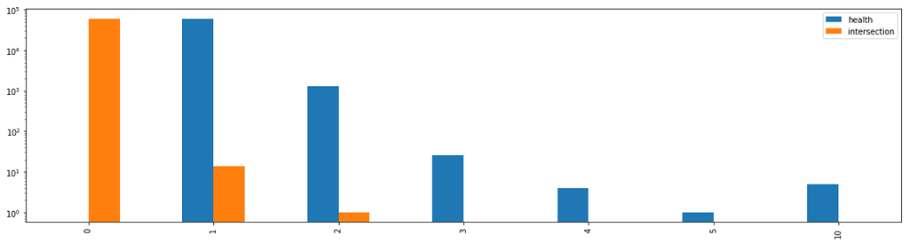

```python
df_histogram_number_of_mentions = pd.DataFrame(data=histogram_number_of_mentions)
df_histogram_number_of_mentions.plot.bar(logy=True, figsize=(20,5))
```

### Network graphs of word/hashtag co-occurrence on intersection tweets

Blue nodes are health keywords, green nodes are climate keywords and red nodes are hashtags. The closer the nodes are to each other, the more often the words co-occur.

#### Network graph of co-occurrence of health and climate keywords

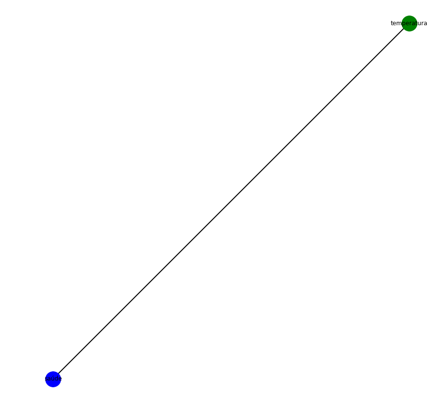

```python
import matplotlib.pyplot as plt
import networkx as nx
import numpy as np


G = nx.Graph()

health_nodes = []
climate_nodes = []

for word1 in cooccurrence_matrix.keys():
    for word2 in cooccurrence_matrix[word1].keys():
        if cooccurrence_matrix[word1][word2] > language_ref[language]['min_coocurrence']:
            G.add_edge(word1, word2, weight=cooccurrence_matrix[word1][word2])
            health_nodes.append(word1)
            climate_nodes.append(word2)

plt.figure(figsize=(15,15))

pos = nx.spring_layout(G)
nx.draw_networkx_nodes(G, pos, nodelist=health_nodes, node_size=1000, node_color='b')
nx.draw_networkx_nodes(G, pos, nodelist=climate_nodes, node_size=1000, node_color='g')
nx.draw_networkx_edges(G, pos, edgelist=G.edges(data=True), width=2)
nx.draw_networkx_labels(G, pos, font_size=12, font_family='sans-serif')

plt.axis('off')
plt.show()
```

#### Network graph of co-occurrence of keywords (health or climate) and general hashtags

Only occurrences in intersection tweets are considered

```python
G = nx.Graph()

health_nodes = []
climate_nodes = []
hashtag_nodes = []

for word in mixed_cooccurrence_matrix.keys():
    for hashtag in mixed_cooccurrence_matrix[word].keys():
        if mixed_cooccurrence_matrix[word][hashtag] > language_ref[language]['min_coocurrence']:
            G.add_edge(word, hashtag, weight=mixed_cooccurrence_matrix[word][hashtag])
            hashtag_nodes.append(hashtag)
            if word in health_dict:
                health_nodes.append(word)
            if word in climate_dict:
                climate_nodes.append(word)

plt.figure(figsize=(15,15))

pos = nx.spring_layout(G)
nx.draw_networkx_nodes(G, pos, nodelist=health_nodes, node_size=1000, node_color='b')
nx.draw_networkx_nodes(G, pos, nodelist=climate_nodes, node_size=1000, node_color='g')
nx.draw_networkx_nodes(G, pos, nodelist=hashtag_nodes, node_size=1000, node_color='r')
nx.draw_networkx_edges(G, pos, edgelist=G.edges(data=True), width=2)
nx.draw_networkx_labels(G, pos, font_size=12, font_family='sans-serif')
#edge_labels = nx.get_edge_attributes(G,'weight')
#nx.draw_networkx_edge_labels(G, pos, edge_labels=edge_labels, font_size=10, font_family='sans-serif')

plt.axis('off')
plt.show()
```

[output not shown]

#### Network graph of co-occurrence of hashtags

Only occurrences in intersection tweets are considered

```python
G = nx.Graph()

nodes = []
for htag1 in hashtags_cooccurrence_matrix.keys():
    for htag2 in hashtags_cooccurrence_matrix[htag1].keys():
        if hashtags_cooccurrence_matrix[htag1][htag2] > language_ref[language]['min_coocurrence_hashtags']:
            G.add_edge(htag1, htag2, weight=hashtags_cooccurrence_matrix[htag1][htag2])
            nodes.append(htag1)
            nodes.append(htag2)


plt.figure(figsize=(15,15))

pos = nx.spring_layout(G)
nx.draw_networkx_nodes(G, pos, nodelist=nodes, node_size=1000)
nx.draw_networkx_edges(G, pos, edgelist=G.edges(data=True), width=2)
nx.draw_networkx_labels(G, pos, font_size=12, font_family='sans-serif')
#edge_labels = nx.get_edge_attributes(G,'weight')
#nx.draw_networkx_edge_labels(G, pos, edge_labels=edge_labels, font_size=10, font_family='sans-serif')

plt.axis('off')
plt.show()
```

[output not shown]

### Sentiment of tweets including relevant references per year: total

```python
df_per_sentiment = pd.DataFrame(data=per_sentiment, index=["positive", "neutral", "negative", "objective", "subjective"])
df_per_sentiment
```

|  | health | intersection |
| --- | --- | --- |
| positive | NaN | NaN |
| neutral | NaN | NaN |
| negative | NaN | NaN |
| objective | NaN | NaN |
| subjective | NaN | NaN |

[figure not shown]

```python
df_per_sentiment.T.filter(items=["health"],axis=0).plot.bar(figsize=(20,5))
```

[figure not shown]

```python
df_per_sentiment.T.filter(items=["intersection"],axis=0).plot.bar(figsize=(20,5))
```

### References per date: total, average, proportion

```python
df_per_date = pd.DataFrame(data=per_date)
df_per_date
```

|  | health | intersection |
| --- | --- | --- |
| 8 2018 | 61498 | 16 |

[figure not shown]

```python
ax = df_per_date.plot.line(figsize=(15,5))
ax.set_xlabel("Date")
ax.set_ylabel("Total number of references")
ax
```

```python
df_average_per_date = pd.DataFrame(data=average_per_date)
df_average_per_date
```

|  | health | intersection |
| --- | --- | --- |
| 8 2018 | 1.023414 | 0.000266 |

[figure not shown]

```python
ax = df_average_per_date.plot.line(figsize=(15,5))
ax.set_xlabel("Date")
ax.set_ylabel("Average number of references")
ax
```

```python
df_proportion_per_date = pd.DataFrame(data=proportion_per_date)
df_proportion_per_date
```

|  | health | intersection |
| --- | --- | --- |
| 8 2018 | 100.0 | 0.024962 |

[figure not shown]

```python
ax = df_proportion_per_date.plot.line(figsize=(15,5))
ax.set_xlabel("Date")
ax.set_ylabel("Proportion of tweets (%)")
ax.set_ylim(ymin=0)
ax
```

### References per location: total, average, proportion

```python
df_per_location = pd.DataFrame(data=per_location)
df_per_location.sort_values(by=['intersection'], ascending=False).head(100)
```

|  | health | intersection |
| --- | --- | --- |
| Petrópolis, Brasil | 114 | 2 |
| not_specified | 14311 | 2 |
| São Paulo, Brasil | 1466 | 1 |
| Portugal | 198 | 1 |
| Santos, Brasil | 58 | 1 |
| 011 | 42 | 0 |
| Ribeirão Preto, Brasil | 28 | 0 |
| Porto Alegre, RS | 29 | 0 |
| Porto Velho, Brasil | 61 | 0 |
| Porto, Portugal | 115 | 0 |
| RJ | 118 | 0 |
| Realengo, Rio de Janeiro | 24 | 0 |
| Recife | 62 | 0 |
| Recife, Brasil | 208 | 0 |
| Rio Branco, Brasil | 34 | 0 |
| Rio | 24 | 0 |
| Porto Alegre, Brasil | 282 | 0 |
| Rio Grande do Sul | 49 | 0 |
| Rio Grande do Sul, Brasil | 207 | 0 |
| Rio Grande, Brasil | 25 | 0 |
| Rio das Ostras, Brasil | 36 | 0 |
| Rio de Janeiro | 514 | 0 |
| Rio de Janeiro | 43 | 0 |
| Rio de Janeiro - Brasil | 39 | 0 |
| Rio de Janeiro, Brasil | 2185 | 0 |
| Rio de Janeiro, Brazil | 83 | 0 |
| Porto Alegre, Brazil | 27 | 0 |
| Piracicaba, Brasil | 21 | 0 |
| Porto Alegre | 94 | 0 |
| Rj | 46 | 0 |
| ... | ... | ... |
| na sua | 67 | 0 |
| na sua | 29 | 0 |
| no seu coração | 29 | 0 |
| rio de janeiro | 51 | 0 |
| rj | 94 | 0 |
| sp | 40 | 0 |
| São Paulo - Brasil | 52 | 0 |
| São Paulo | 22 | 0 |
| São Paulo | 457 | 0 |
| Sete Lagoas | 97 | 0 |
| Salvador | 39 | 0 |
| Salvador, Brasil | 126 | 0 |
| Santa Catarina, Brasil | 148 | 0 |
| Santa Cruz, Rio de Janeiro | 29 | 0 |
| Santa Maria, Brasil | 36 | 0 |
| Santo André, Brasil | 36 | 0 |
| Sao Paulo | 25 | 0 |
| Sao Paulo, Brazil | 111 | 0 |
| Serra, Brasil | 26 | 0 |
| Sete Lagoas - BH | 65 | 0 |
| São Luís, Brasil | 87 | 0 |
| Sete Lagoas, Brasil | 2285 | 0 |
| Sete Lagoas, Minas Gerais | 645 | 0 |
| Sorocaba, Brasil | 31 | 0 |
| São Bernardo do Campo, Brasil | 39 | 0 |
| São Gonçalo, Brasil | 73 | 0 |
| São José dos Campos, Brasil | 51 | 0 |
| São José dos Pinhais, Brasil | 24 | 0 |
| São João de Meriti, Brasil | 44 | 0 |
| São Leopoldo, Brasil | 22 | 0 |

100 rows × 2 columns

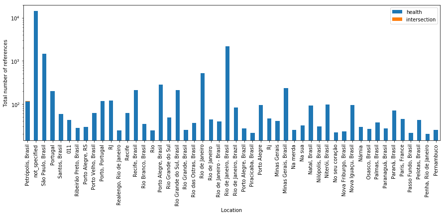

```python
ax = df_per_location.sort_values(by=['intersection'], ascending=False).head(50).plot.bar(stacked=True,figsize=(15,5), logy=True)
ax.set_xlabel("Location")
ax.set_ylabel("Total number of references")
ax
```

```python
df_average_per_location = pd.DataFrame(data=average_per_location)
df_average_per_location.sort_values(by=['intersection'], ascending=False).head(100)
```

|  | health | intersection |
| --- | --- | --- |
| Santos, Brasil | 1.035714 | 0.017857 |
| Petrópolis, Brasil | 1.008850 | 0.017699 |
| Portugal | 1.020619 | 0.005155 |
| São Paulo, Brasil | 1.025892 | 0.000700 |
| not_specified | 1.024116 | 0.000143 |
| 011 | 1.000000 | 0.000000 |
| Ribeirão Preto, Brasil | 1.000000 | 0.000000 |
| Porto Alegre, RS | 1.035714 | 0.000000 |
| Porto Velho, Brasil | 1.016667 | 0.000000 |
| Porto, Portugal | 1.036036 | 0.000000 |
| RJ | 1.008547 | 0.000000 |
| Realengo, Rio de Janeiro | 1.000000 | 0.000000 |
| Recife | 1.068966 | 0.000000 |
| Recife, Brasil | 1.019608 | 0.000000 |
| Rio Branco, Brasil | 1.062500 | 0.000000 |
| Rio | 1.043478 | 0.000000 |
| Porto Alegre, Brasil | 1.021739 | 0.000000 |
| Rio Grande do Sul | 1.065217 | 0.000000 |
| Rio Grande do Sul, Brasil | 1.014706 | 0.000000 |
| Rio Grande, Brasil | 1.000000 | 0.000000 |
| Rio das Ostras, Brasil | 1.000000 | 0.000000 |
| Rio de Janeiro | 1.042596 | 0.000000 |
| Rio de Janeiro | 1.023810 | 0.000000 |
| Rio de Janeiro - Brasil | 1.026316 | 0.000000 |
| Rio de Janeiro, Brasil | 1.021028 | 0.000000 |
| Rio de Janeiro, Brazil | 1.024691 | 0.000000 |
| Porto Alegre, Brazil | 1.080000 | 0.000000 |
| Piracicaba, Brasil | 1.050000 | 0.000000 |
| Porto Alegre | 1.021739 | 0.000000 |
| Rj | 1.000000 | 0.000000 |
| ... | ... | ... |
| na sua | 1.015152 | 0.000000 |
| na sua | 1.000000 | 0.000000 |
| no seu coração | 1.035714 | 0.000000 |
| rio de janeiro | 1.040816 | 0.000000 |
| rj | 1.000000 | 0.000000 |
| sp | 1.000000 | 0.000000 |
| São Paulo - Brasil | 1.019608 | 0.000000 |
| São Paulo | 1.000000 | 0.000000 |
| São Paulo | 1.031603 | 0.000000 |
| Sete Lagoas | 1.000000 | 0.000000 |
| Salvador | 1.054054 | 0.000000 |
| Salvador, Brasil | 1.032787 | 0.000000 |
| Santa Catarina, Brasil | 1.072464 | 0.000000 |
| Santa Cruz, Rio de Janeiro | 1.035714 | 0.000000 |
| Santa Maria, Brasil | 1.028571 | 0.000000 |
| Santo André, Brasil | 1.000000 | 0.000000 |
| Sao Paulo | 1.000000 | 0.000000 |
| Sao Paulo, Brazil | 1.018349 | 0.000000 |
| Serra, Brasil | 1.000000 | 0.000000 |
| Sete Lagoas - BH | 1.000000 | 0.000000 |
| São Luís, Brasil | 1.060976 | 0.000000 |
| Sete Lagoas, Brasil | 1.000000 | 0.000000 |
| Sete Lagoas, Minas Gerais | 1.000000 | 0.000000 |
| Sorocaba, Brasil | 1.033333 | 0.000000 |
| São Bernardo do Campo, Brasil | 1.000000 | 0.000000 |
| São Gonçalo, Brasil | 1.000000 | 0.000000 |
| São José dos Campos, Brasil | 1.000000 | 0.000000 |
| São José dos Pinhais, Brasil | 1.000000 | 0.000000 |
| São João de Meriti, Brasil | 1.023256 | 0.000000 |
| São Leopoldo, Brasil | 1.000000 | 0.000000 |

100 rows × 2 columns

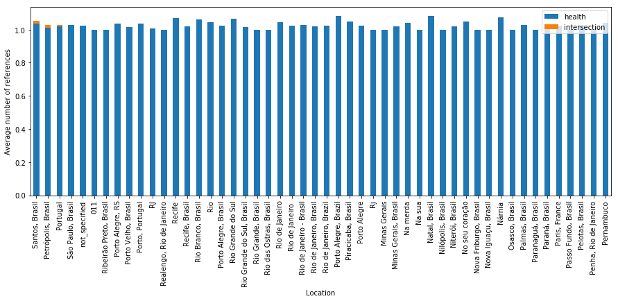

```python
ax = df_average_per_location.sort_values(by=['intersection'], ascending=False).head(50).plot.bar(stacked=True,figsize=(15,5))
ax.set_xlabel("Location")
ax.set_ylabel("Average number of references")
ax
```

```python
df_proportion_per_location = pd.DataFrame(data=proportion_per_location)
df_proportion_per_location.sort_values(by=['intersection'], ascending=False).head(100)
```

|  | health | intersection |
| --- | --- | --- |
| Santos, Brasil | 100.0 | 1.785714 |
| Petrópolis, Brasil | 100.0 | 1.769912 |
| Portugal | 100.0 | 0.515464 |
| São Paulo, Brasil | 100.0 | 0.069979 |
| not_specified | 100.0 | 0.014312 |
| 011 | 100.0 | 0.000000 |
| Ribeirão Preto, Brasil | 100.0 | 0.000000 |
| Porto Alegre, RS | 100.0 | 0.000000 |
| Porto Velho, Brasil | 100.0 | 0.000000 |
| Porto, Portugal | 100.0 | 0.000000 |
| RJ | 100.0 | 0.000000 |
| Realengo, Rio de Janeiro | 100.0 | 0.000000 |
| Recife | 100.0 | 0.000000 |
| Recife, Brasil | 100.0 | 0.000000 |
| Rio Branco, Brasil | 100.0 | 0.000000 |
| Rio | 100.0 | 0.000000 |
| Porto Alegre, Brasil | 100.0 | 0.000000 |
| Rio Grande do Sul | 100.0 | 0.000000 |
| Rio Grande do Sul, Brasil | 100.0 | 0.000000 |
| Rio Grande, Brasil | 100.0 | 0.000000 |
| Rio das Ostras, Brasil | 100.0 | 0.000000 |
| Rio de Janeiro | 100.0 | 0.000000 |
| Rio de Janeiro | 100.0 | 0.000000 |
| Rio de Janeiro - Brasil | 100.0 | 0.000000 |
| Rio de Janeiro, Brasil | 100.0 | 0.000000 |
| Rio de Janeiro, Brazil | 100.0 | 0.000000 |
| Porto Alegre, Brazil | 100.0 | 0.000000 |
| Piracicaba, Brasil | 100.0 | 0.000000 |
| Porto Alegre | 100.0 | 0.000000 |
| Rj | 100.0 | 0.000000 |
| ... | ... | ... |
| na sua | 100.0 | 0.000000 |
| na sua | 100.0 | 0.000000 |
| no seu coração | 100.0 | 0.000000 |
| rio de janeiro | 100.0 | 0.000000 |
| rj | 100.0 | 0.000000 |
| sp | 100.0 | 0.000000 |
| São Paulo - Brasil | 100.0 | 0.000000 |
| São Paulo | 100.0 | 0.000000 |
| São Paulo | 100.0 | 0.000000 |
| Sete Lagoas | 100.0 | 0.000000 |
| Salvador | 100.0 | 0.000000 |
| Salvador, Brasil | 100.0 | 0.000000 |
| Santa Catarina, Brasil | 100.0 | 0.000000 |
| Santa Cruz, Rio de Janeiro | 100.0 | 0.000000 |
| Santa Maria, Brasil | 100.0 | 0.000000 |
| Santo André, Brasil | 100.0 | 0.000000 |
| Sao Paulo | 100.0 | 0.000000 |
| Sao Paulo, Brazil | 100.0 | 0.000000 |
| Serra, Brasil | 100.0 | 0.000000 |
| Sete Lagoas - BH | 100.0 | 0.000000 |
| São Luís, Brasil | 100.0 | 0.000000 |
| Sete Lagoas, Brasil | 100.0 | 0.000000 |
| Sete Lagoas, Minas Gerais | 100.0 | 0.000000 |
| Sorocaba, Brasil | 100.0 | 0.000000 |
| São Bernardo do Campo, Brasil | 100.0 | 0.000000 |
| São Gonçalo, Brasil | 100.0 | 0.000000 |
| São José dos Campos, Brasil | 100.0 | 0.000000 |
| São José dos Pinhais, Brasil | 100.0 | 0.000000 |
| São João de Meriti, Brasil | 100.0 | 0.000000 |
| São Leopoldo, Brasil | 100.0 | 0.000000 |

100 rows × 2 columns

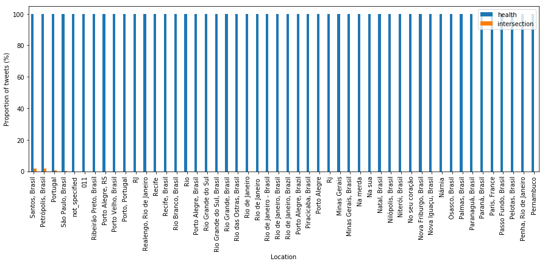

```python
ax = df_proportion_per_location.sort_values(by=['intersection'], ascending=False).head(50).plot.bar(figsize=(15,5))
ax.set_xlabel("Location")
ax.set_ylabel("Proportion of tweets (%)")
ax
```

### References per sender (Twitter username): total and proportion

```python
df_per_user = pd.DataFrame(data=per_user)
df_per_user.sort_values(by=['intersection'], ascending=False).head(50)
```

|  | health | intersection |
| --- | --- | --- |
| @miguelitohunter | 1 | 2 |
| @voz_petropolis | 53 | 2 |
| @bii_cool | 1 | 1 |
| @castagna_a | 1 | 1 |
| @JeniferDiasDos2 | 2 | 1 |
| @profeborto | 1 | 1 |
| @_phebs | 1 | 1 |
| @SNS_Portugal | 16 | 1 |
| @CPTM_oficial | 1 | 1 |
| @_markitin | 1 | 1 |
| @kamilladiasR | 1 | 1 |
| @belagg | 1 | 1 |
| @sellyoursoulsz | 3 | 1 |
| @marianarajao | 1 | 1 |
| @jmngzz | 1 | 0 |
| @jmducorte5 | 2 | 0 |
| @jmanfrini | 1 | 0 |
| @jmariaffc | 1 | 0 |
| @jmpdacruz | 1 | 0 |
| @jmb1710 | 2 | 0 |
| @jmdiasr | 1 | 0 |
| @jmoriw | 1 | 0 |
| @jmepnunes | 1 | 0 |
| @jmelor_ | 1 | 0 |
| @jmmariar | 1 | 0 |
| @jmoniqs | 1 | 0 |
| @jmichaelvicent | 1 | 0 |
| @jmiguelcastro18 | 1 | 0 |
| @jm_nipples | 2 | 0 |
| @jminpalet | 1 | 0 |
| @jmoledo_ | 1 | 0 |
| @jmachado1994 | 1 | 0 |
| @0000bruja | 3 | 0 |
| @jm_news | 2 | 0 |
| @jm19214 | 1 | 0 |
| @jjuliacris | 1 | 0 |
| @jjup_ | 1 | 0 |
| @jjvzin | 1 | 0 |
| @jkarinef | 1 | 0 |
| @jkbeatus | 1 | 0 |
| @jkfonsecaa | 1 | 0 |
| @jkrj_70 | 2 | 0 |
| @jl_emici | 1 | 0 |
| @jl_td2 | 1 | 0 |
| @jldiniz1 | 3 | 0 |
| @jleites58 | 3 | 0 |
| @jlfleite | 1 | 0 |
| @jlgoncalez | 1 | 0 |
| @jliaPaulinelli1 | 1 | 0 |
| @jllopes10 | 1 | 0 |

```python
df_proportion_per_user = pd.DataFrame(data=proportion_per_user)
df_proportion_per_user.sort_values(by=['intersection'], ascending=False).head(50)
```

|  | health | intersection |
| --- | --- | --- |
| @voz_petropolis | 0.086182 | 12.50 |
| @CPTM_oficial | 0.001626 | 6.25 |
| @JeniferDiasDos2 | 0.003252 | 6.25 |
| @SNS_Portugal | 0.026017 | 6.25 |
| @_markitin | 0.001626 | 6.25 |
| @_phebs | 0.001626 | 6.25 |
| @belagg | 0.001626 | 6.25 |
| @bii_cool | 0.001626 | 6.25 |
| @castagna_a | 0.001626 | 6.25 |
| @kamilladiasR | 0.001626 | 6.25 |
| @marianarajao | 0.001626 | 6.25 |
| @miguelitohunter | 0.001626 | 6.25 |
| @profeborto | 0.001626 | 6.25 |
| @sellyoursoulsz | 0.004878 | 6.25 |
| @0000bruja | 0.004878 | NaN |
| @000Morena000 | 0.001626 | NaN |
| @000xfelp | 0.003252 | NaN |
| @001Flamenguista | 0.001626 | NaN |
| @00DAXM | 0.001626 | NaN |
| @00DDX | 0.001626 | NaN |
| @00DMI | 0.001626 | NaN |
| @00_fanboy | 0.001626 | NaN |
| @00_tapuia | 0.001626 | NaN |
| @00h44 | 0.001626 | NaN |
| @0118gizbi | 0.001626 | NaN |
| @011SY | 0.001626 | NaN |
| @013Danisantos | 0.001626 | NaN |
| @013_clandestina | 0.001626 | NaN |
| @019vine | 0.001626 | NaN |
| @01BelieberdoJB | 0.001626 | NaN |
| @01CarolSilva | 0.001626 | NaN |
| @01Chloee | 0.003252 | NaN |
| @01Frosch | 0.001626 | NaN |
| @01Sarinhaa | 0.001626 | NaN |
| @01boulevard | 0.001626 | NaN |
| @0208Gomes | 0.001626 | NaN |
| @021Tt2L | 0.001626 | NaN |
| @021_favelado | 0.001626 | NaN |
| @021_tayna | 0.001626 | NaN |
| @021crf | 0.001626 | NaN |
| @021flap | 0.001626 | NaN |
| @021porextenso | 0.001626 | NaN |
| @021tiquen | 0.001626 | NaN |
| @027Costa | 0.001626 | NaN |
| @027Godoy | 0.001626 | NaN |
| @027_Piffer | 0.001626 | NaN |
| @027writer | 0.001626 | NaN |
| @02MorenaSantos | 0.001626 | NaN |
| @03CarlosAlberto | 0.003252 | NaN |
| @0404Lucas | 0.001626 | NaN |

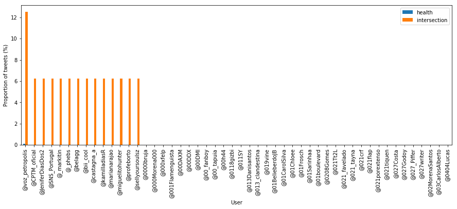

```python
ax = df_proportion_per_user.sort_values(by=['intersection'], ascending=False).head(50).plot.bar(figsize=(15,5))
ax.set_xlabel("User")
ax.set_ylabel("Proportion of tweets (%)")
ax
```

### Frenquency of keywords: health and climate

```python
df_health_keywords = pd.DataFrame(sorted(global_count_health_keywords.items(), key=lambda k: k[1], reverse=True), columns=["Keyword", "Number of mentions"])
df_health_keywords
```

|  | Keyword | Number of mentions |
| --- | --- | --- |
| 0 | saúde | 28605 |
| 1 | doença | 8986 |
| 2 | saúde_pública | 1435 |
| 3 | sarampo | 957 |
| 4 | mortalidade | 726 |
| 5 | infecção | 487 |
| 6 | nutrição | 486 |
| 7 | pneumonia | 477 |
| 8 | epidemia | 314 |
| 9 | diarréia | 163 |
| 10 | desnutrição | 115 |
| 11 | malária | 86 |
| 12 | transtorno_mental | 33 |
| 13 | epidemiologia | 28 |
| 14 | poluição_do_ar | 8 |
| 15 | pandemia | 6 |
| 16 | sars | 3 |
| 17 | retardo_de_crescimento | 1 |

```python
df_climate_keywords = pd.DataFrame(sorted(global_count_climate_keywords.items(), key=lambda k: k[1], reverse=True), columns=["Keyword", "Number of mentions"])
df_climate_keywords
```

|  | Keyword | Number of mentions |
| --- | --- | --- |
| 0 | temperatura | 13 |
| 1 | mudanças_climáticas | 1 |
| 2 | aquecimento_global | 1 |
| 3 | energia_renovável | 1 |

### Word clouds: health, climate, intersection

Up to 200 most frequent words that appear in the context of our health or climate keywords or both

```python
import matplotlib.pyplot as plt
import collections
from wordcloud import WordCloud, STOPWORDS
from stop_words import get_stop_words

threshold = 200

language_specific_stopwords = get_stop_words(language)

def create_wordcloud(contexts, stopwords=[]):
    most_frequent_words = {}
    stopwords.extend(STOPWORDS)
    stopwords.extend(language_specific_stopwords)

    context_unigrams = collections.Counter(contexts)
    for word, freq in sorted(context_unigrams.items(), key=lambda k: k[1], reverse=True)[0:threshold]:
        if word not in stopwords:
            most_frequent_words[word] = freq

    wordcloud = WordCloud(background_color="white", scale=10).generate_from_frequencies(most_frequent_words)

    fig = plt.figure(1, figsize=(20, 12))
    plt.axis('off')
    plt.imshow(wordcloud, interpolation='bilinear')
    plt.show()
```

#### Contexts for health keywords

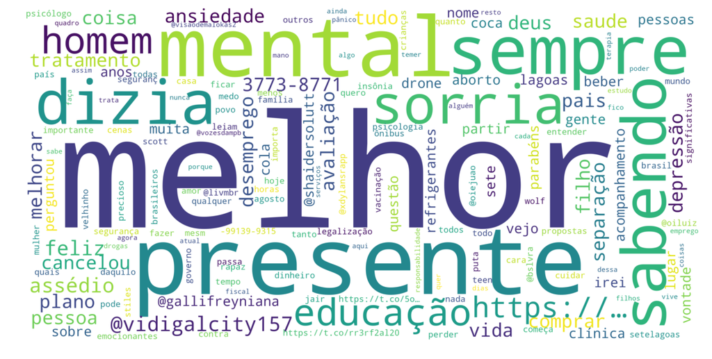

```python
create_wordcloud(global_health_contexts, health_dict + ['https'])
```

#### Contexts for intersection tweets (excludes health and climate keywords)

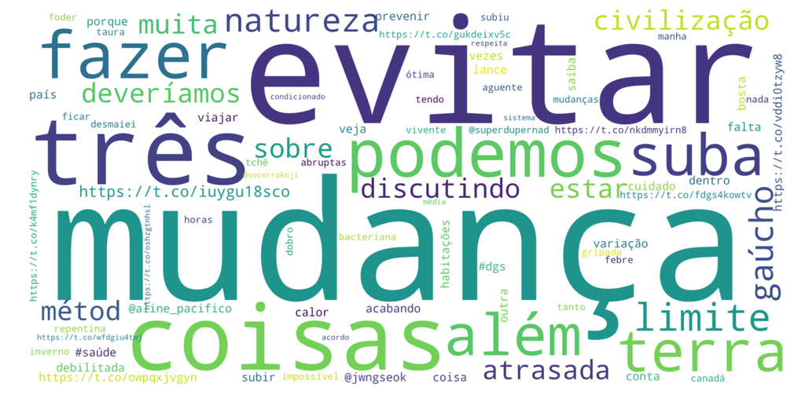

```python
create_wordcloud(global_intersection_contexts, climate_dict + health_dict + ["https"])
```

#### Contexts for intersection tweets (includes the found health and climate keywords)

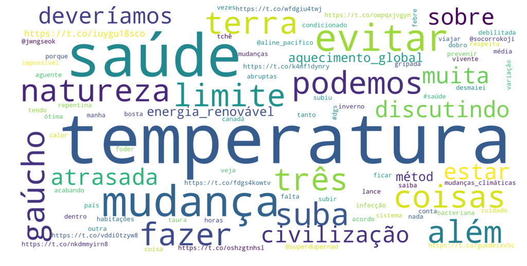

```python
create_wordcloud(global_intersection_contexts, ["https"])
```

#### Hashtags that appear in tweets containing health keywords

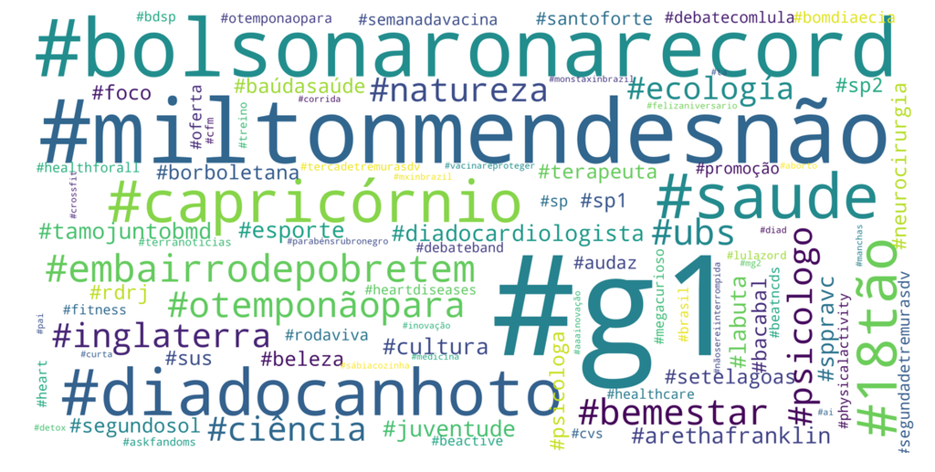

```python
lowercase_hashtags = []
for hashtag in global_health_hashtag_contexts:
    lowercase_hashtags.append(hashtag.lower())
create_wordcloud(lowercase_hashtags, health_hashtag_dict + ["https"])
```

#### Hashtags that appear in tweets containing the intersection of health and climate keywords

[figure not shown]

```python
lowercase_hashtags = []
for hashtag in global_intersection_hashtag_contexts:
    lowercase_hashtags.append(hashtag.lower())
create_wordcloud(lowercase_hashtags, ["https"])
```

#### User mentions that appear in tweets containing health keywords

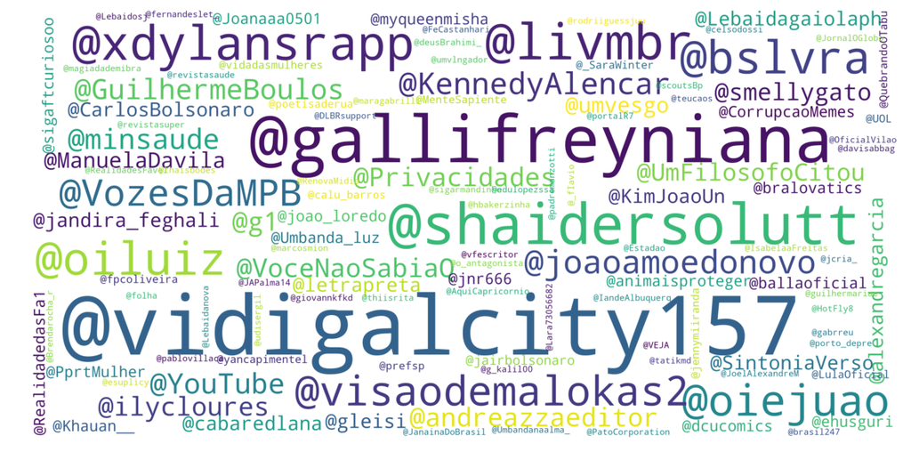

```python
create_wordcloud(global_health_user_mentions_contexts)
```

#### User mentions that appear in tweets containing the intersection of health and climate keywords

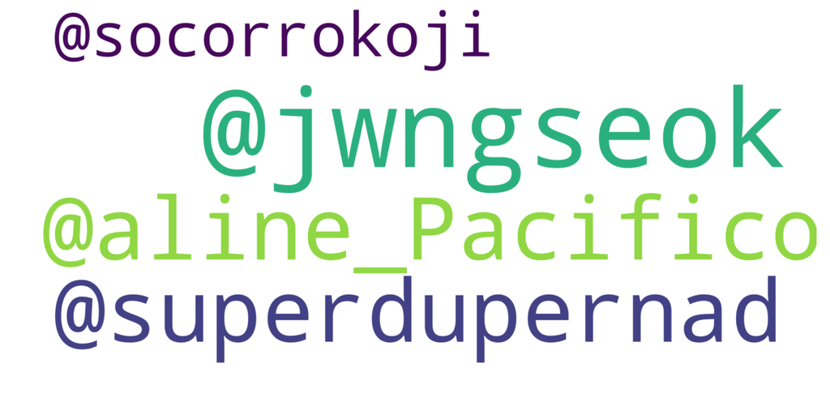

```python
create_wordcloud(global_intersection_user_mentions_contexts)
```